# Trabalho de Estatística

##### 3.2.1 Correlação entre as variáveis independentes (RunTime e Budget) e a variável dependente (USGross)

As correlações entre a variável dependente e as duas variáveis independentes foram averiguadas com um *scatterplot*. Abaixo, é possível observar uma correlação positiva entre a variável dependente (`USGross`) e ambas as variáveis independentes.

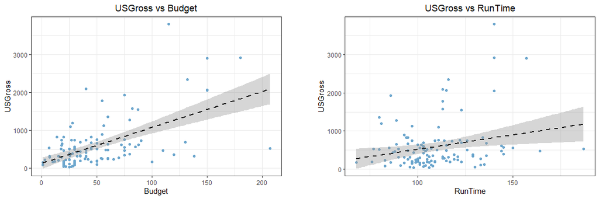

```r
smo1 <- ggplot(movie_budgets, aes(x = Budget, y = USGross)) +
  geom_point(color = "skyblue3") +
  geom_smooth(method = "lm", se = TRUE, color = "grey10", linetype = "dashed") +
 theme_bw() +
   ggtitle("USGross vs Budget") +
       labs(x = "Budget") +
       labs(y = "USGross") +
  theme(plot.title = element_text(hjust = 0.5))

smo2 <- ggplot(movie_budgets, aes(x = RunTime, y = USGross)) +
  geom_point(color = "skyblue3") +
  geom_smooth(method = "lm", se = TRUE, color = "grey10", linetype = "dashed") +
  theme_bw() +
  ggtitle("USGross vs RunTime") +
       labs(x = "RunTime") +
       labs(y = "USGross") +
  theme(plot.title = element_text(hjust = 0.5))
spacer <- textGrob(" ", gp = gpar(fontsize = 1))
grid.arrange(smo1, spacer, smo2, ncol=3,widths = c(10, 1, 10))
```

### 4. Modelo de Regressão

Para a análise do ajuste do modelo, temos que formular a hipótese nula e a hipótese alternativa, representadas abaixo:

- $H0:$ Não existe uma relação significativa entre as variáveis independentes e a variável dependente.
- $H1:$ Existe uma relação significativa entre as variáveis independentes e a variável dependente.

A próxima etapa consiste em formular e avaliar os modelos de cada um dos 3 *datasets*.

#### 4.1. Modelo do Dataset original - implementação

```r
# Modelo com todas as variáveis
model_full <- lm(USGross ~ Budget + RunTime + Genre , data = movie_budgets)
summary(model_full)
```

```
##
## Call:
## lm(formula = USGross ~ Budget + RunTime + Genre, data = movie_budgets)
##
## Residuals:
##      Min       1Q   Median       3Q      Max
## -1481.65  -265.28   -72.75   168.08  2422.55
##
## Coefficients:
##                Estimate Std. Error t value   Pr(>|t|)
## (Intercept)     117.365    355.849   0.330     0.7422
## Budget            9.712      1.647   5.897 0.00000004 ***
## RunTime          -1.452      3.411  -0.426     0.6711
## GenreAdventure  349.140    181.086   1.928     0.0564 .
## GenreComedy     227.515    147.636   1.541     0.1261
## GenreDrama      151.497    163.216   0.928     0.3553
## GenreHorror     129.734    189.893   0.683     0.4959
## GenreThriller   -78.060    244.126  -0.320     0.7498
## ---
## Signif. codes:  0 '***' 0.001 '**' 0.01 '*' 0.05 '.' 0.1 ' ' 1
##
## Residual standard error: 516.9 on 112 degrees of freedom
## Multiple R-squared:  0.3697, Adjusted R-squared:  0.3304
## F-statistic: 9.387 on 7 and 112 DF,  p-value: 0.000000004051
```

Neste modelo completo, verificamos que apenas a variável Budget é significativa, assumindo um nivel de significância de $\alpha=0.05$. O $R^2$ é de aproximadamente 37%, indicando que o modelo de regressão explica 37% da variabilidade da variável dependente com base nas variáveis independentes incluídas no modelo. Por outras palavras, 37% da variação observada na variável dependente pode ser explicada pelas variáveis independentes do modelo. Este valor é relativamente baixo, o que poderá ser devido a outros fatores não considerados ou à variabilidade aleatória.

```r
# Modelo com apenas a variável significativa - Budget
model_budget <- lm(USGross ~ Budget, data = movie_budgets)
summary(model_budget)
```

```
##
## Call:
## lm(formula = USGross ~ Budget, data = movie_budgets)
##
## Residuals:
##      Min       1Q   Median       3Q      Max
## -1563.94  -269.50   -60.62   148.45  2582.93
##
## Coefficients:
##             Estimate Std. Error t value         Pr(>|t|)
## (Intercept)  131.901     76.130   1.733           0.0858 .
## Budget         9.460      1.235   7.662 0.00000000000562 ***
## ---
## Signif. codes:  0 '***' 0.001 '**' 0.01 '*' 0.05 '.' 0.1 ' ' 1
##
## Residual standard error: 518.3 on 118 degrees of freedom
## Multiple R-squared:  0.3323, Adjusted R-squared:  0.3266
## F-statistic: 58.71 on 1 and 118 DF,  p-value: 0.000000000005618
```

Ao retirarmos as variáveis não significativas, verifica-se que o $R^2$ diminui de 37% para 33%, aproximadamente, indicando que apenas 4% da variabilidade é explicada pelas variáveis `RunTime` e `Genre`. Deste modo, podemos rejeitar $H0$, uma vez que poderá haver uma relação significativa entre as variáveis independentes e a variável dependente em estudo.

##### 4.1.1. Análise Stepwise do Modelo

A análise stepwise do modelo permite identificar que variáveis devem ser incorporadas, de modo a obter o modelo com a melhor performance. Detalhadamente, foram usados os métodos `both`, `forward` e `backward`.

```r
model_aic_bo <- stepAIC(model_full, direction = "both", trace = FALSE)
summary(model_aic_bo)
```

```
##
## Call:
## lm(formula = USGross ~ Budget, data = movie_budgets)
##
## Residuals:
##      Min       1Q   Median       3Q      Max
## -1563.94  -269.50   -60.62   148.45  2582.93
##
## Coefficients:
##             Estimate Std. Error t value         Pr(>|t|)
## (Intercept)  131.901     76.130   1.733           0.0858 .
## Budget         9.460      1.235   7.662 0.00000000000562 ***
## ---
## Signif. codes:  0 '***' 0.001 '**' 0.01 '*' 0.05 '.' 0.1 ' ' 1
##
## Residual standard error: 518.3 on 118 degrees of freedom
## Multiple R-squared:  0.3323, Adjusted R-squared:  0.3266
## F-statistic: 58.71 on 1 and 118 DF,  p-value: 0.000000000005618
```

```r
model_aic_f <- stepAIC(model_full, direction = "forward", trace = FALSE)
summary(model_aic_f)
```

```
##
## Call:
## lm(formula = USGross ~ Budget + RunTime + Genre, data = movie_budgets)
##
## Residuals:
##      Min       1Q   Median       3Q      Max
## -1481.65  -265.28   -72.75   168.08  2422.55
##
## Coefficients:
##                Estimate Std. Error t value   Pr(>|t|)
## (Intercept)     117.365    355.849   0.330     0.7422
## Budget            9.712      1.647   5.897 0.00000004 ***
## RunTime          -1.452      3.411  -0.426     0.6711
## GenreAdventure  349.140    181.086   1.928     0.0564 .
## GenreComedy     227.515    147.636   1.541     0.1261
## GenreDrama      151.497    163.216   0.928     0.3553
## GenreHorror     129.734    189.893   0.683     0.4959
## GenreThriller   -78.060    244.126  -0.320     0.7498
## ---
## Signif. codes:  0 '***' 0.001 '**' 0.01 '*' 0.05 '.' 0.1 ' ' 1
##
## Residual standard error: 516.9 on 112 degrees of freedom
## Multiple R-squared:  0.3697, Adjusted R-squared:  0.3304
## F-statistic: 9.387 on 7 and 112 DF,  p-value: 0.000000004051
```

```r
model_aic_b <- stepAIC(model_full, direction = "backward", trace = FALSE)
summary(model_aic_b)
```

```
##
## Call:
## lm(formula = USGross ~ Budget, data = movie_budgets)
##
## Residuals:
##      Min       1Q   Median       3Q      Max
## -1563.94  -269.50   -60.62   148.45  2582.93
##
## Coefficients:
##             Estimate Std. Error t value         Pr(>|t|)
## (Intercept)  131.901     76.130   1.733           0.0858 .
## Budget         9.460      1.235   7.662 0.00000000000562 ***
## ---
## Signif. codes:  0 '***' 0.001 '**' 0.01 '*' 0.05 '.' 0.1 ' ' 1
##
## Residual standard error: 518.3 on 118 degrees of freedom
## Multiple R-squared:  0.3323, Adjusted R-squared:  0.3266
## F-statistic: 58.71 on 1 and 118 DF,  p-value: 0.000000000005618
```

```r
AIC(model_aic_bo)
```

```
## [1] 1844.682
```

```r
AIC(model_aic_f)
```

```
## [1] 1849.747
```

```r
AIC(model_aic_b)
```

```
## [1] 1844.682
```

A análise stepwise aparenta estar em concordância com a nossa análise. Através desta análise, verificamos que os métodos `both` e `backward` apresentam o mesmo valor AIC, enquanto que o método `forward` apresenta um valor de AIC mais elevado. Assim sendo, o modelo com a melhor performance foi obtido pelo método `both` e `backward`, que inclui apenas a variável `Budget`.

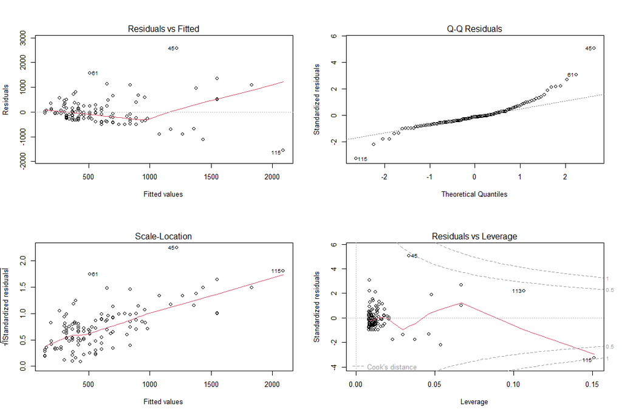

```r
par(mfrow=c(2,2))
plot(model_aic_bo)
```

Os gráficos de diagnóstico acima indicam que os dados do modelo apresentam heterocedasticidade e uma distribuição não gaussiana.